From: https://github.com/ksatola

# Predict Boston House Prices

Concerns housing values in suburbs of Boston.

- Downloaded from: https://archive.ics.uci.edu/ml/machine-learning-databases/housing/

## Problem

Predict a house price

## Dataset attributes

Each record in the database describes a Boston suburb or town. The data was drawn from the Boston Standard Metropolitan Statistical Area (SMSA) in 1970. The attributes are defined as follows (taken from the UCI Machine Learning Repository):

1. CRIM: per capita crime rate by town
2. ZN: proportion of residential land zoned for lots over 25,000 sq.ft.
3. INDUS: proportion of non-retail business acres per town
4. CHAS: Charles River dummy variable (= 1 if tract bounds river; 0 otherwise)
5. NOX: nitric oxides concentration (parts per 10 million)
6. RM: average number of rooms per dwelling
7. AGE: proportion of owner-occupied units built prior to 1940
8. DIS: weighted distances to five Boston employment centers
9. RAD: index of accessibility to radial highways
10. TAX: full-value property-tax rate per \$10,000
11. PTRATIO: pupil-teacher ratio by town
12. B: 1000(Bk − 0.63) where Bk is the proportion of blacks by town
13. LSTAT: % lower status of the population
14. MEDV: Median value of owner-occupied homes in \$1000s

More on the dataset: housing.names

# Imports

```python
# Load libraries
import numpy as np
import pandas as pd
from pandas.plotting import scatter_matrix
import matplotlib.pyplot as plt

from pickle import dump
from pickle import load

from sklearn.preprocessing import StandardScaler
from sklearn.model_selection import train_test_split
from sklearn.model_selection import KFold
from sklearn.model_selection import cross_val_score
from sklearn.model_selection import GridSearchCV

from sklearn.linear_model import LinearRegression
from sklearn.linear_model import Lasso
from sklearn.linear_model import ElasticNet
from sklearn.tree import DecisionTreeRegressor
from sklearn.neighbors import KNeighborsRegressor
from sklearn.svm import SVR

from sklearn.pipeline import Pipeline
from sklearn.ensemble import RandomForestRegressor
from sklearn.ensemble import GradientBoostingRegressor
from sklearn.ensemble import ExtraTreesRegressor
from sklearn.ensemble import AdaBoostRegressor
from sklearn.metrics import mean_squared_error

from numpy import set_printoptions
pd.set_option('display.width', 100)
pd.set_option('precision', 3)

%matplotlib inline
```

# Load the dataset

```python
# Load dataset
filename = 'housing.data'
names = ['CRIM', 'ZN', 'INDUS', 'CHAS', 'NOX', 'RM', 'AGE', 'DIS', 'RAD', 'TAX', 'PTRATIO', 'B', 'LSTAT', 'MEDV']
df = pd.read_csv(filename, names=names, delim_whitespace=True)
```

# Sumarize the dataset

```python
df.shape
```

```
(506, 14)
```

```python
# Peek at the data itself
#df.head(20)
df.sample(10)
```

|  | CRIM | ZN | INDUS | CHAS | NOX | RM | AGE | DIS | RAD | TAX | PTRATIO | B | LSTAT | MEDV |
| --- | --- | --- | --- | --- | --- | --- | --- | --- | --- | --- | --- | --- | --- | --- |
| 92 | 0.042 | 28.0 | 15.04 | 0 | 0.464 | 6.442 | 53.6 | 3.666 | 4 | 270.0 | 18.2 | 395.01 | 8.16 | 22.9 |
| 132 | 0.590 | 0.0 | 21.89 | 0 | 0.624 | 6.372 | 97.9 | 2.327 | 4 | 437.0 | 21.2 | 385.76 | 11.12 | 23.0 |
| 14 | 0.638 | 0.0 | 8.14 | 0 | 0.538 | 6.096 | 84.5 | 4.462 | 4 | 307.0 | 21.0 | 380.02 | 10.26 | 18.2 |
| 505 | 0.047 | 0.0 | 11.93 | 0 | 0.573 | 6.030 | 80.8 | 2.505 | 1 | 273.0 | 21.0 | 396.90 | 7.88 | 11.9 |
| 65 | 0.036 | 80.0 | 3.37 | 0 | 0.398 | 6.290 | 17.8 | 6.612 | 4 | 337.0 | 16.1 | 396.90 | 4.67 | 23.5 |
| 350 | 0.062 | 40.0 | 1.25 | 0 | 0.429 | 6.490 | 44.4 | 8.792 | 1 | 335.0 | 19.7 | 396.90 | 5.98 | 22.9 |
| 434 | 13.913 | 0.0 | 18.10 | 0 | 0.713 | 6.208 | 95.0 | 2.222 | 24 | 666.0 | 20.2 | 100.63 | 15.17 | 11.7 |
| 439 | 9.391 | 0.0 | 18.10 | 0 | 0.740 | 5.627 | 93.9 | 1.817 | 24 | 666.0 | 20.2 | 396.90 | 22.88 | 12.8 |
| 156 | 2.447 | 0.0 | 19.58 | 0 | 0.871 | 5.272 | 94.0 | 1.736 | 5 | 403.0 | 14.7 | 88.63 | 16.14 | 13.1 |
| 435 | 11.160 | 0.0 | 18.10 | 0 | 0.740 | 6.629 | 94.6 | 2.125 | 24 | 666.0 | 20.2 | 109.85 | 23.27 | 13.4 |

```python
df.info()
```

```
<class 'pandas.core.frame.DataFrame'>
RangeIndex: 506 entries, 0 to 505
Data columns (total 14 columns):
CRIM       506 non-null float64
ZN         506 non-null float64
INDUS      506 non-null float64
CHAS       506 non-null int64
NOX        506 non-null float64
RM         506 non-null float64
AGE        506 non-null float64
DIS        506 non-null float64
RAD        506 non-null int64
TAX        506 non-null float64
PTRATIO    506 non-null float64
B          506 non-null float64
LSTAT      506 non-null float64
MEDV       506 non-null float64
dtypes: float64(12), int64(2)
memory usage: 55.4 KB
```

```python
# Are there any missing values?
df.isnull().values.any()
```

```
False
```

```python
# Statistical summary of all attributes
df.describe()
```

|  | CRIM | ZN | INDUS | CHAS | NOX | RM | AGE | DIS | RAD | TAX | PTRATIO | B | LSTAT | MEDV |
| --- | --- | --- | --- | --- | --- | --- | --- | --- | --- | --- | --- | --- | --- | --- |
| count | 506.000 | 506.000 | 506.000 | 506.000 | 506.000 | 506.000 | 506.000 | 506.000 | 506.000 | 506.000 | 506.000 | 506.000 | 506.000 | 506.000 |
| mean | 3.614 | 11.364 | 11.137 | 0.069 | 0.555 | 6.285 | 68.575 | 3.795 | 9.549 | 408.237 | 18.456 | 356.674 | 12.653 | 22.533 |
| std | 8.602 | 23.322 | 6.860 | 0.254 | 0.116 | 0.703 | 28.149 | 2.106 | 8.707 | 168.537 | 2.165 | 91.295 | 7.141 | 9.197 |
| min | 0.006 | 0.000 | 0.460 | 0.000 | 0.385 | 3.561 | 2.900 | 1.130 | 1.000 | 187.000 | 12.600 | 0.320 | 1.730 | 5.000 |
| 25% | 0.082 | 0.000 | 5.190 | 0.000 | 0.449 | 5.886 | 45.025 | 2.100 | 4.000 | 279.000 | 17.400 | 375.377 | 6.950 | 17.025 |
| 50% | 0.257 | 0.000 | 9.690 | 0.000 | 0.538 | 6.208 | 77.500 | 3.207 | 5.000 | 330.000 | 19.050 | 391.440 | 11.360 | 21.200 |
| 75% | 3.677 | 12.500 | 18.100 | 0.000 | 0.624 | 6.623 | 94.075 | 5.188 | 24.000 | 666.000 | 20.200 | 396.225 | 16.955 | 25.000 |
| max | 88.976 | 100.000 | 27.740 | 1.000 | 0.871 | 8.780 | 100.000 | 12.127 | 24.000 | 711.000 | 22.000 | 396.900 | 37.970 | 50.000 |

```python
# Pearson’s Correlation Coefficient assumes a normal distribution of the attributes involved.
df.corr(method='pearson')
```

|  | CRIM | ZN | INDUS | CHAS | NOX | RM | AGE | DIS | RAD | TAX | PTRATIO | B | LSTAT | MEDV |
| --- | --- | --- | --- | --- | --- | --- | --- | --- | --- | --- | --- | --- | --- | --- |
| CRIM | 1.000 | -0.200 | 0.407 | -0.056 | 0.421 | -0.219 | 0.353 | -0.380 | 0.626 | 0.583 | 0.290 | -0.385 | 0.456 | -0.388 |
| ZN | -0.200 | 1.000 | -0.534 | -0.043 | -0.517 | 0.312 | -0.570 | 0.664 | -0.312 | -0.315 | -0.392 | 0.176 | -0.413 | 0.360 |
| INDUS | 0.407 | -0.534 | 1.000 | 0.063 | 0.764 | -0.392 | 0.645 | -0.708 | 0.595 | 0.721 | 0.383 | -0.357 | 0.604 | -0.484 |
| CHAS | -0.056 | -0.043 | 0.063 | 1.000 | 0.091 | 0.091 | 0.087 | -0.099 | -0.007 | -0.036 | -0.122 | 0.049 | -0.054 | 0.175 |
| NOX | 0.421 | -0.517 | 0.764 | 0.091 | 1.000 | -0.302 | 0.731 | -0.769 | 0.611 | 0.668 | 0.189 | -0.380 | 0.591 | -0.427 |
| RM | -0.219 | 0.312 | -0.392 | 0.091 | -0.302 | 1.000 | -0.240 | 0.205 | -0.210 | -0.292 | -0.356 | 0.128 | -0.614 | 0.695 |
| AGE | 0.353 | -0.570 | 0.645 | 0.087 | 0.731 | -0.240 | 1.000 | -0.748 | 0.456 | 0.506 | 0.262 | -0.274 | 0.602 | -0.377 |
| DIS | -0.380 | 0.664 | -0.708 | -0.099 | -0.769 | 0.205 | -0.748 | 1.000 | -0.495 | -0.534 | -0.232 | 0.292 | -0.497 | 0.250 |
| RAD | 0.626 | -0.312 | 0.595 | -0.007 | 0.611 | -0.210 | 0.456 | -0.495 | 1.000 | 0.910 | 0.465 | -0.444 | 0.489 | -0.382 |
| TAX | 0.583 | -0.315 | 0.721 | -0.036 | 0.668 | -0.292 | 0.506 | -0.534 | 0.910 | 1.000 | 0.461 | -0.442 | 0.544 | -0.469 |
| PTRATIO | 0.290 | -0.392 | 0.383 | -0.122 | 0.189 | -0.356 | 0.262 | -0.232 | 0.465 | 0.461 | 1.000 | -0.177 | 0.374 | -0.508 |
| B | -0.385 | 0.176 | -0.357 | 0.049 | -0.380 | 0.128 | -0.274 | 0.292 | -0.444 | -0.442 | -0.177 | 1.000 | -0.366 | 0.333 |
| LSTAT | 0.456 | -0.413 | 0.604 | -0.054 | 0.591 | -0.614 | 0.602 | -0.497 | 0.489 | 0.544 | 0.374 | -0.366 | 1.000 | -0.738 |
| MEDV | -0.388 | 0.360 | -0.484 | 0.175 | -0.427 | 0.695 | -0.377 | 0.250 | -0.382 | -0.469 | -0.508 | 0.333 | -0.738 | 1.000 |

## Observations

# Visualize the dataset

## Univariate plots

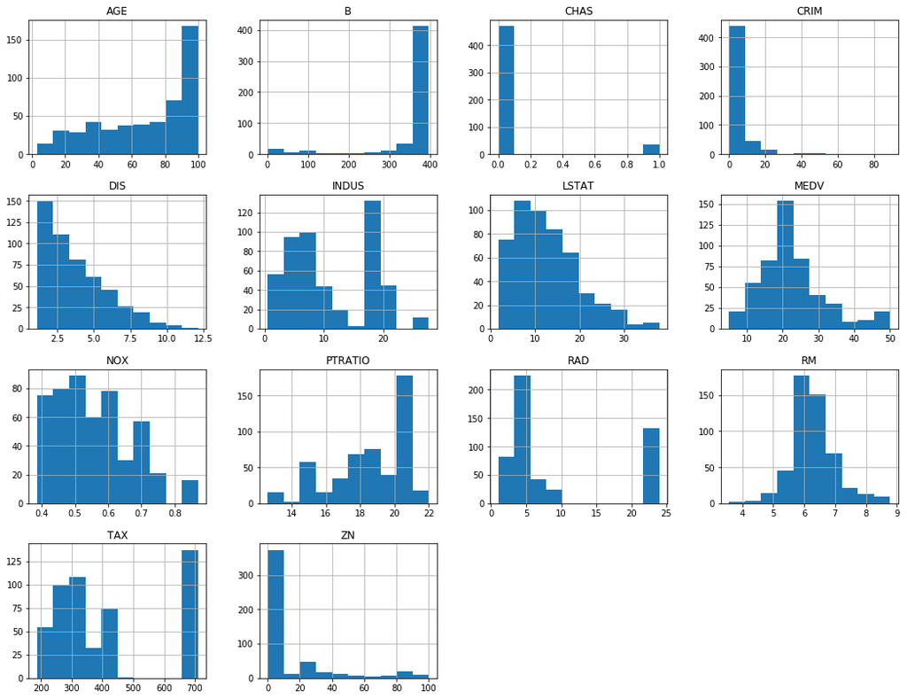

```python
# Histograms
df.hist(figsize=(18,14), sharex=False, sharey=False, layout=(4,4));
```

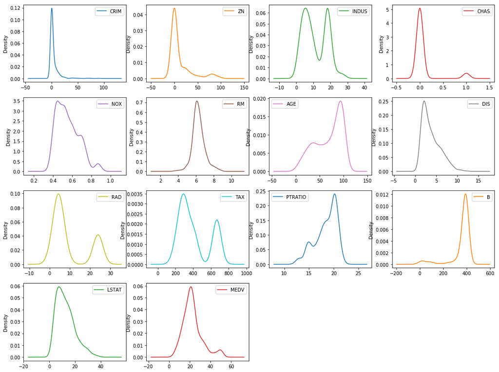

```python
# Density plots
df.plot(kind='density', subplots=True, layout=(4,4), sharex=False, figsize=(18, 14));
```

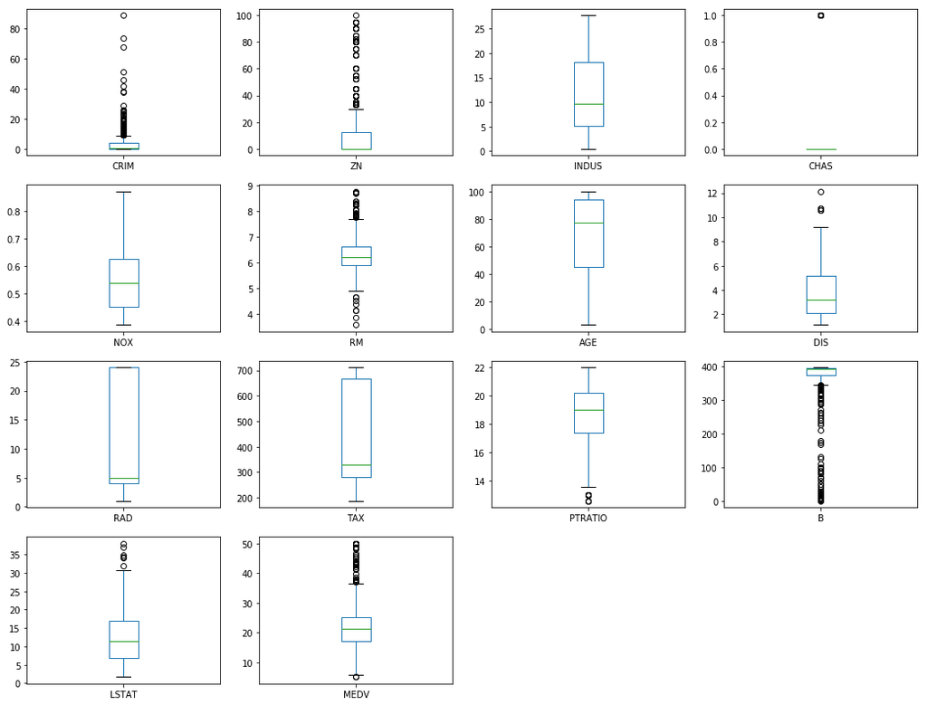

```python
# Box and whisker plots
df.plot(kind='box', subplots=True, layout=(4,4), sharex=False, sharey=False, figsize=(18,14));
```

### Observations

- histograms
  - AGE, B, CRIM and ZN may have exponential distribution.
  - RAD and TAX may have bimodal distribution.
- density plots
  - It looks like NOX, RM and LSTAT may be skewed Gaussian distriutions.
- box plots
  - CRIM, ZN, RM and B have many outliers.
  - CHAS has one (or more with the similar value).

## Multivariate plots

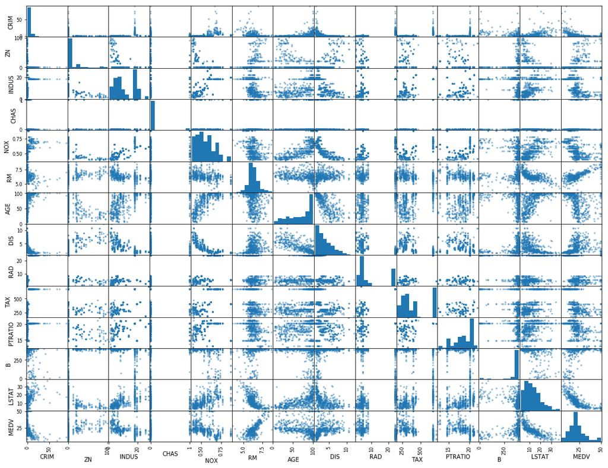

```python
# Scatter plot matrix
scatter_matrix(df, figsize=(18,14));
```

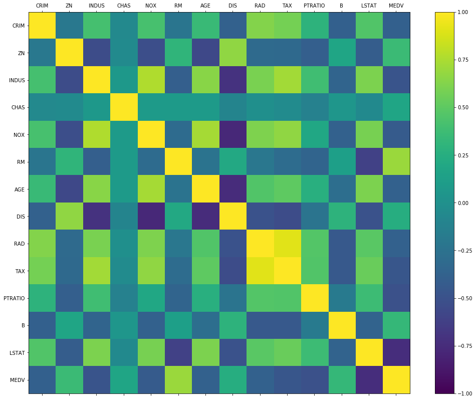

```python
correlations = df.corr()

# Plot correlation matrix
fig = plt.figure(figsize=(18,14))
ax = fig.add_subplot(111)
cax = ax.matshow(correlations, vmin=-1, vmax=1, interpolation='none')
fig.colorbar(cax)
ticks = np.arange(0, 14, 1)
ax.set_xticks(ticks)
ax.set_yticks(ticks)
ax.set_xticklabels(names)
ax.set_yticklabels(names)
plt.show()
```

### Observtions

- scatter plot matrix
  - Some of the higher correlated attributes do show good structure in their relationship (eg. DIS and AGE, NOX and LSTAT). Not of them are linear, but nice predictable curved relationships (eg. DIS and NOX, AGE and NOX).

## Next steps

It would be worth trying:

- Feature selection and removing the most correlated attributes.
- Normalizing the dataset to reduce the effect of differing scales.
- Standardizing the dataset to reduce the effects of differing distributions.

# Test dataset

To confirm the accuracy of our final model. It is a smoke test that we can use to see if we messed up and to give us confidence on our estimates of accuracy on unseen data. We will use 80% of the dataset for modeling and hold back 20% for validation.

```python
# Separate data into training and validation datasets
arr = df.values
X = arr[:,0:13]
y = arr[:,13]
test_size = 0.2
seed = 7
X_train, X_test, Y_train, Y_test = train_test_split(X, y, test_size=test_size, random_state=seed)
```

# Algorithms evaluation

The dataset is not too small. We will evaluate algorithms using the Mean Squared Error (MSE) metric. MSE will give a gross idea of how wrong all predictions are (0 is perfect).

```
LR: -2137.9855726678684 (941.4263656984774)
LASSO: -2642.356110840965 (1165.1109915777915)
EN: -2750.2259350661698 (1230.5022264112704)
KNN: -4189.648839024391 (1390.1688149849865)
CART: -2552.184817073171 (1287.380285348906)
SVR: -8551.834183929132 (3199.479823184288)
```

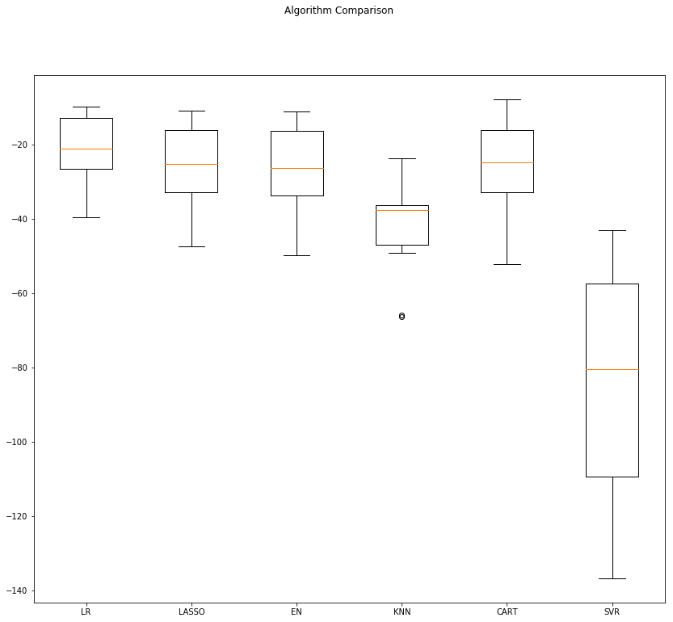

```python
# The baseline

# Test options and evaluation metric
num_folds = 10
seed = 7
scoring = 'neg_mean_squared_error'

# Spot-Check Algorithms
models = []
models.append(('LR', LinearRegression()))
models.append(('LASSO', Lasso()))
models.append(('EN', ElasticNet()))
models.append(('KNN', KNeighborsRegressor()))
models.append(('CART', DecisionTreeRegressor()))
models.append(('SVR', SVR(gamma='auto')))

def eval_algorithms(models, show_boxplots=True):
    # Evaluate each model in turn
    # Setup the test harness to use 10-fold cross validation
    results = []
    names = []
    for name, model in models:
        kfold = KFold(n_splits=10, random_state=seed)
        cv_results = cross_val_score(model, X_train, Y_train, cv=kfold, scoring=scoring)
        results.append(cv_results)
        names.append(name)
        #print("Estimated accuracy of {} with the mean of {} and std. dev. {}".format(name, cv_results.mean()*100.0, cv_results.std()*100.0))
        print("{}: {} ({})".format(name, cv_results.mean()*100.0, cv_results.std()*100.0))

    if show_boxplots:
        # Create a plot of the model evaluation results to compae the spread
        # and the estimated mean accuracy of each model
        fig = plt.figure(figsize=(14,12))
        fig.suptitle('Algorithm Comparison')
        ax = fig.add_subplot(111)
        plt.boxplot(results)
        ax.set_xticklabels(names)
        plt.show()

eval_algorithms(models)
```

It looks like LR has the lowest MSE.

The differing scales of the data is probably hurting the skill of all of the algorithms and perhaps more for SVR and KNN. Let's standardize data and run tests again (standardization = each attriobute has a mean value of zero and a standard deviation of 1). To avaid data leakage when we transform, we use pipelines.

```
ScaledLR: -2137.9855726678566 (941.4263656984714)
ScaledLASSO: -2660.7313557676616 (897.8761485890262)
ScaledEN: -2793.2372158135513 (1058.7490490139403)
ScaledKNN: -2010.7620487804877 (1237.6949150820471)
ScaledCART: -2787.9528658536583 (1363.1397883613859)
ScaledSVR: -2963.3085500303214 (1700.9186052351556)
```

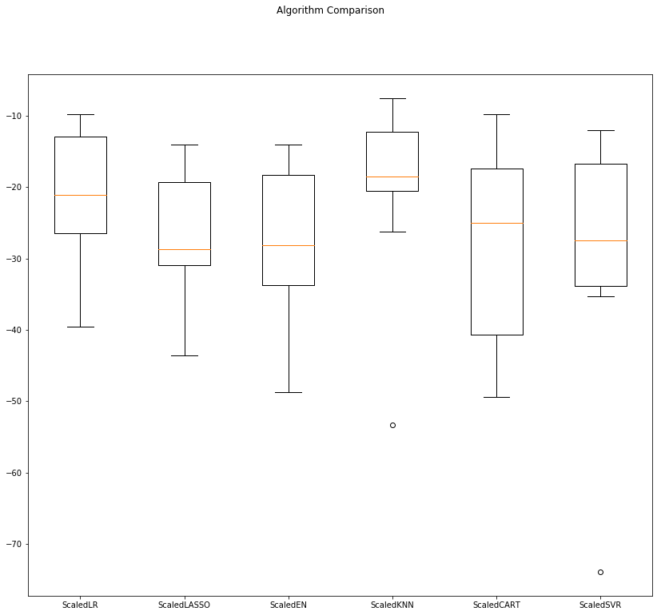

```python
# Standardize the dataset
pipelines = []
pipelines.append(('ScaledLR', Pipeline([('Scaler', StandardScaler()),('LR', LinearRegression())])))
pipelines.append(('ScaledLASSO', Pipeline([('Scaler', StandardScaler()),('LASSO', Lasso())])))
pipelines.append(('ScaledEN', Pipeline([('Scaler', StandardScaler()),('EN', ElasticNet())])))
pipelines.append(('ScaledKNN', Pipeline([('Scaler', StandardScaler()),('KNN', KNeighborsRegressor())])))
pipelines.append(('ScaledCART', Pipeline([('Scaler', StandardScaler()),('CART', DecisionTreeRegressor())])))
pipelines.append(('ScaledSVR', Pipeline([('Scaler', StandardScaler()),('SVR', SVR())])))

eval_algorithms(pipelines)
```

Standardization revealed a new leader: KNN. KNN has both a tight distribution of error and has the lowest median score.

# Improve results with algorithm tuning

The default number of neighbors in KNN is 5. We can use grid search to try a set of different numbers of neighbors and see if the score can be improved.

```python
# KNN Algorithm tuning
scaler = StandardScaler().fit(X_train)
rescaledX = scaler.transform(X_train)
k_values = np.array([1,3,5,7,9,11,13,15,17,19,21])
param_grid = dict(n_neighbors=k_values)
model = KNeighborsRegressor()
kfold = KFold(n_splits=num_folds, random_state=seed)
grid = GridSearchCV(estimator=model, param_grid=param_grid, scoring=scoring, cv=kfold, iid=False)
grid_result = grid.fit(rescaledX, Y_train)

# Print results
print("Best: {} using {}".format(grid_result.best_score_, grid_result.best_params_))
means = grid_result.cv_results_['mean_test_score']
stds = grid_result.cv_results_['std_test_score']
params = grid_result.cv_results_['params']
for mean, stdev, param in zip(means, stds, params):
    print("{} ({}) with: {}".format(mean, stdev, param))
```

```
Best: -18.10930386178861 using {'n_neighbors': 3}
-20.169640243902442 (14.986903589095084) with: {'n_neighbors': 1}
-18.10930386178861 (12.880861011784255) with: {'n_neighbors': 3}
-20.063115219512195 (12.138331105197853) with: {'n_neighbors': 5}
-20.514296801891486 (12.278135599828225) with: {'n_neighbors': 7}
-20.319535584161393 (11.554508789696914) with: {'n_neighbors': 9}
-20.963145086676075 (11.540906942920092) with: {'n_neighbors': 11}
-21.099039810939527 (11.870961990115173) with: {'n_neighbors': 13}
-21.506842653116532 (11.468311063771333) with: {'n_neighbors': 15}
-22.739137332264328 (11.499596087059038) with: {'n_neighbors': 17}
-23.829011318491997 (11.277558018572918) with: {'n_neighbors': 19}
-24.320892489353465 (11.849666867506965) with: {'n_neighbors': 21}
```

```
ScaledKNN: -1818.7979403794036 (1281.4003556104506)
```

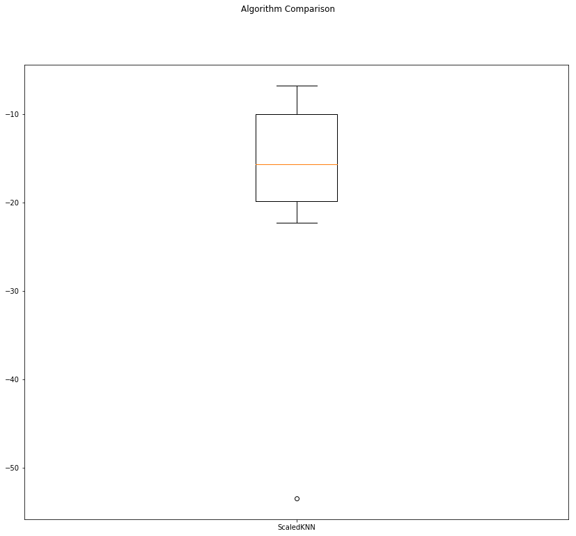

```python
# Check if we have improvement
models = []
models.append(('ScaledKNN', Pipeline([('Scaler', StandardScaler()),('KNN', KNeighborsRegressor(n_neighbors=3))])))
eval_algorithms(models)
```

# Improve results with ensemble methods

- Boosting Methods: AdaBoost (AB) and Gradient Boosting (GBM).
- Bagging Methods: Random Forests (RF) and Extra Trees (ET).

```
ScaledAB: -1486.1921837251084 (670.9480781035891)
ScaledGBM: -1013.8410442630006 (447.7817699285531)
ScaledRF: -1254.7149620548782 (699.9472929881159)
ScaledET: -908.0509660487797 (503.00257899074904)
```

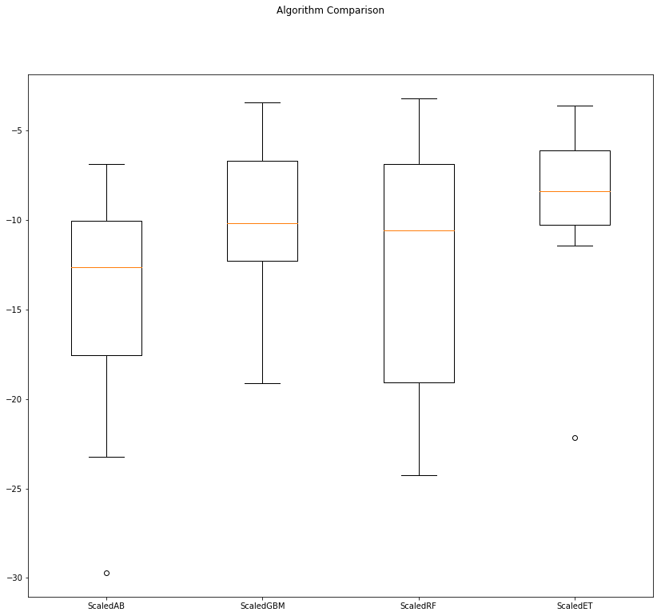

```python
# Ensembles
ensembles = []
ensembles.append(('ScaledAB', Pipeline([('Scaler', StandardScaler()),('AB', AdaBoostRegressor())])))
ensembles.append(('ScaledGBM', Pipeline([('Scaler', StandardScaler()),('GBM', GradientBoostingRegressor())])))
ensembles.append(('ScaledRF', Pipeline([('Scaler', StandardScaler()),('RF', RandomForestRegressor(n_estimators=100))])))
ensembles.append(('ScaledET', Pipeline([('Scaler', StandardScaler()),('ET', ExtraTreesRegressor(n_estimators=100))])))

eval_algorithms(ensembles)
```

It seems that Extra Trees has the best median score. Maybe tuning ensemble algorithms make the scoring better.

## Tune ensemble methods

The default number of tree in the forest is 100. This is a good candidate for tuning.

```python
# Tune scaled GBM
scaler = StandardScaler().fit(X_train)
rescaledX = scaler.transform(X_train)
param_grid = dict(n_estimators=np.array([50,100,150,200,250,300,350,400]))
model = ExtraTreesRegressor(random_state=seed)
kfold = KFold(n_splits=num_folds, random_state=seed)
grid = GridSearchCV(estimator=model, param_grid=param_grid, scoring=scoring, cv=kfold, iid=False)
grid_result = grid.fit(rescaledX, Y_train)

# Print results
print("Best: {} using {}".format(grid_result.best_score_, grid_result.best_params_))
means = grid_result.cv_results_['mean_test_score']
stds = grid_result.cv_results_['std_test_score']
params = grid_result.cv_results_['params']
for mean, stdev, param in zip(means, stds, params):
    print("{} ({}) with: {}".format(mean, stdev, param))
```

```
Best: -8.866016964603661 using {'n_estimators': 200}
-9.859604313902441 (5.606602783203686) with: {'n_estimators': 50}
-9.217081936280483 (5.3406940229635405) with: {'n_estimators': 100}
-8.918976559485086 (5.220815646529518) with: {'n_estimators': 150}
-8.866016964603661 (5.2027028366359485) with: {'n_estimators': 200}
-8.914178400087811 (5.19752518912607) with: {'n_estimators': 250}
-8.925708994132803 (5.187878148175953) with: {'n_estimators': 300}
-8.950589991702362 (5.192787222740293) with: {'n_estimators': 350}
-8.981708732641037 (5.232555759103061) with: {'n_estimators': 400}
```

```
ScaledET: -918.4098782362797 (569.6008358510587)
```

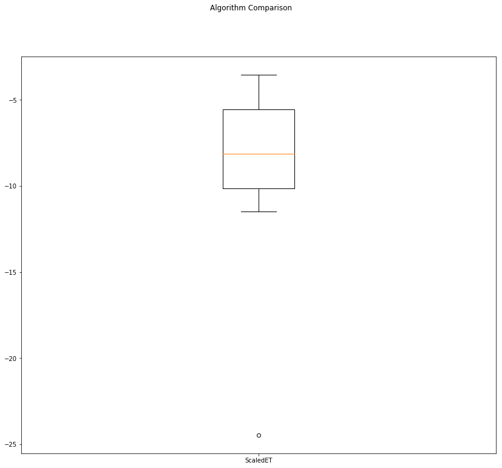

```python
# Check if we have improvement
models = []
models.append(('ScaledET', Pipeline([('Scaler', StandardScaler()),('ET', ExtraTreesRegressor(n_estimators=200))])))
eval_algorithms(models)
```

# Finalize model

Finalize the ScaledET model and test it on a test dataset. Prepare the model and train it on the entire training dataset. This includes standardizing the training dataset before training.

```python
# Prepare the model
scaler = StandardScaler().fit(X_train)
rescaledX = scaler.transform(X_train)
model = ExtraTreesRegressor(n_estimators=200, random_state=seed)
#model = KNeighborsRegressor(n_neighbors=3)
model.fit(rescaledX, Y_train)
```

```
ExtraTreesRegressor(bootstrap=False, criterion='mse', max_depth=None,
          max_features='auto', max_leaf_nodes=None,
          min_impurity_decrease=0.0, min_impurity_split=None,
          min_samples_leaf=1, min_samples_split=2,
          min_weight_fraction_leaf=0.0, n_estimators=200, n_jobs=None,
          oob_score=False, random_state=7, verbose=0, warm_start=False)
```

```python
# Scale the inputs for the validation dataset and generate predictions
# Transform the test dataset
rescaledTestX = scaler.transform(X_test)
predictions = model.predict(rescaledTestX)

print('Estimated MSE:')
eval_algorithms(models, show_boxplots=False)
print('MSE: {}'.format(mean_squared_error(Y_test, predictions)))

result = model.score(X_test, Y_test)
print('Score: {}'.format(result))
```

```
Estimated MSE:
ScaledET: -920.0963187820118 (552.363808423593)
MSE: 13.81404784803921
Score: 0.02242657225366218
```

# Save results

```python
# Save the model to disk
filename = 'finalized_model.sav'
dump(model, open(filename, 'wb'))

# Some time later...
# Load the model from disk
loaded_model = load(open(filename, 'rb'))
result = loaded_model.score(X_test, Y_test)
print('Score: {}'.format(result))
```

```
Score: 0.02242657225366218
```